# Tarea_Daniela_Lopez

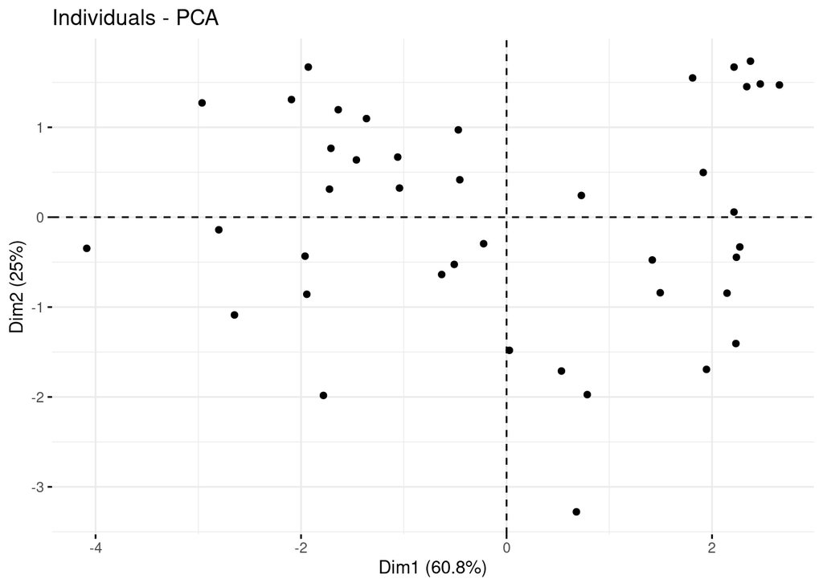

```r
fviz_pca_ind(exp_gen_pca, repel = TRUE,
             label = "none") # label = "none" hide individual labels
```

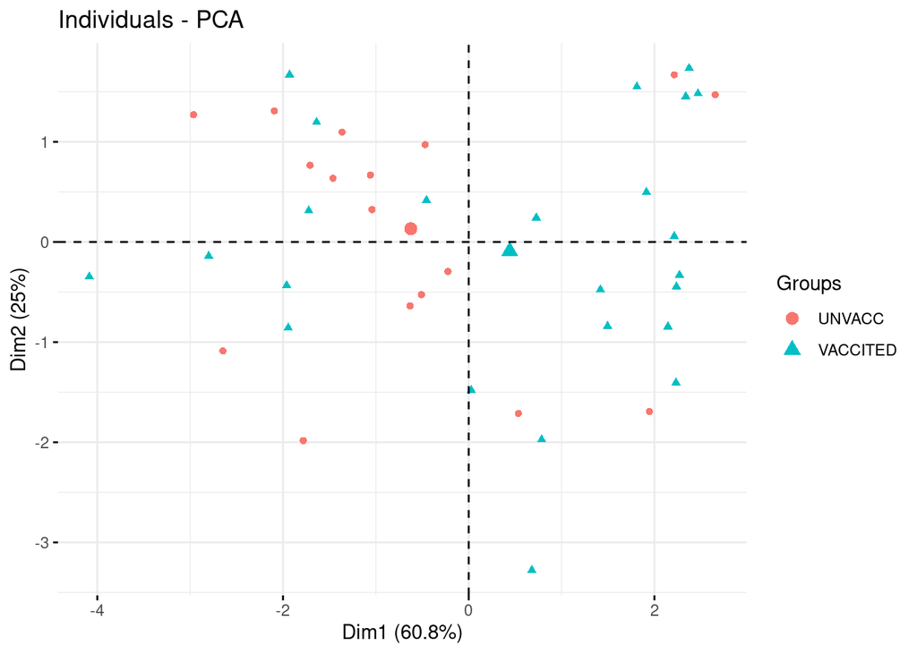

```r
fviz_pca_ind(exp_gen_pca, repel = TRUE,
             label = "none",
             habillage = D_PCA$TREATMENT) # Identifica individuos por factor de clasificación
```

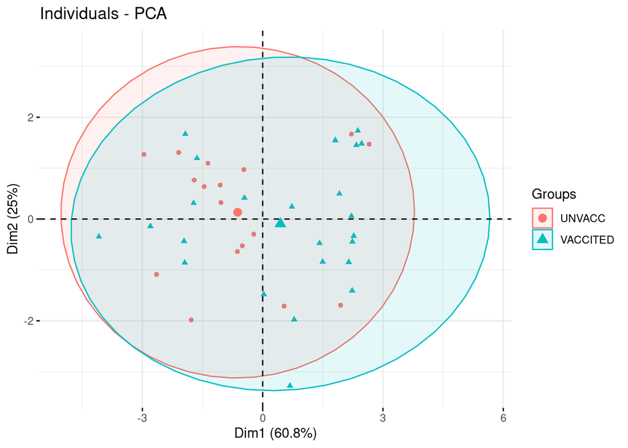

```r
fviz_pca_ind(exp_gen_pca, repel = TRUE,
             label = "none",
             habillage = D_PCA$TREATMENT,
             addEllipses = TRUE) # añade elipses para identificar factores de clasificación
```

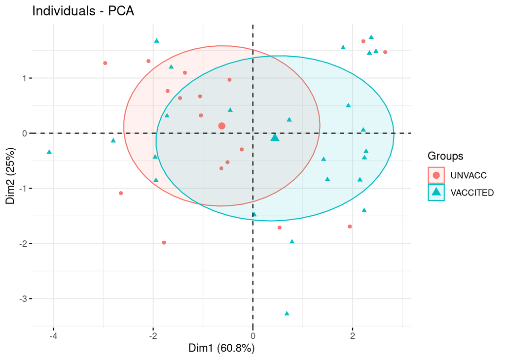

```r
fviz_pca_ind(exp_gen_pca, repel = TRUE,
             label = "none",
             habillage = D_PCA$TREATMENT,
             addEllipses = TRUE,
             ellipse.level=0.5) # ajusta tamaño de elipses (intervalo de confianza).
```

Lso grupos están solapados no hay una separación entre ambos según las varibales, es decir el CT de los genes de los grupos vacunados y no vacunados.

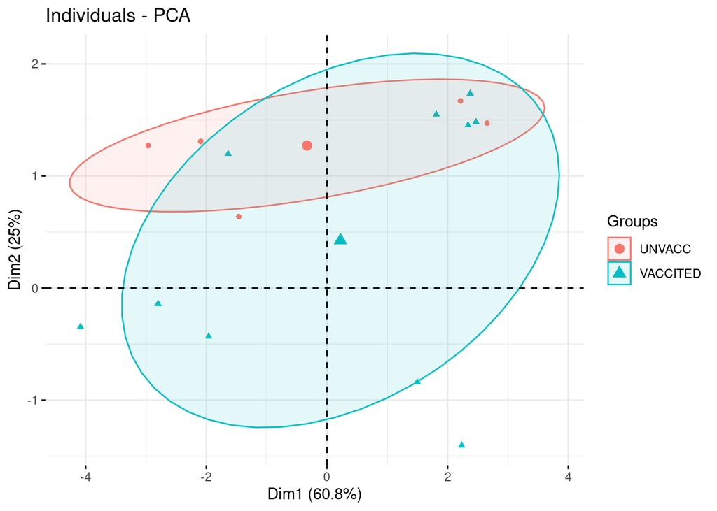

```r
fviz_pca_ind(exp_gen_pca, repel = TRUE,
             label = "none",
             habillage = D_PCA$TREATMENT,
             addEllipses = TRUE,
             ellipse.level=0.60,
             select.ind = list(cos2 = 15)) # selecciona individuos que mas contrbuyen al PCA
```

Seleccionando los individuos que mas constibuyen al PCA igual hay solapamiento

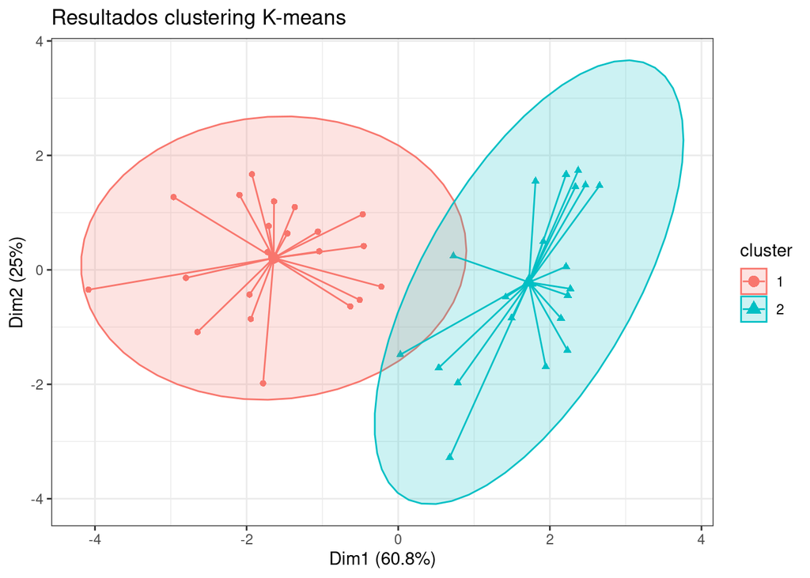

```r
pca.res <- pam(D_PCA_new, 2)
# Visualización
fviz_cluster(pca.res, geom = "point", ellipse.type = "norm",
             show.clust.cent = TRUE,star.plot = TRUE)+
  labs(title = "Resultados clustering K-means")+ theme_bw()
```

Con esta imagen se evidencia disminuye el grado de conflicto entre los clusters 1 y 2, ya que tienen cierta área solapada entre ambos. Esta representacion mezcla cluster y PCA, pero no indican el grado de representación de cada variable en cada uno de los componentes.

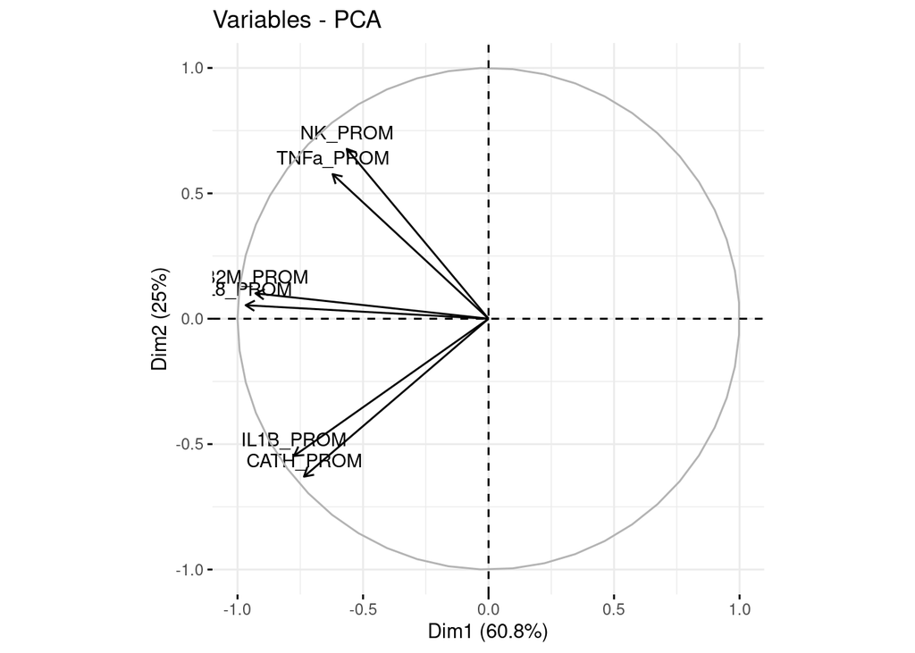

```r
fviz_pca_var(exp_gen_pca, labelsize=0.4)
```

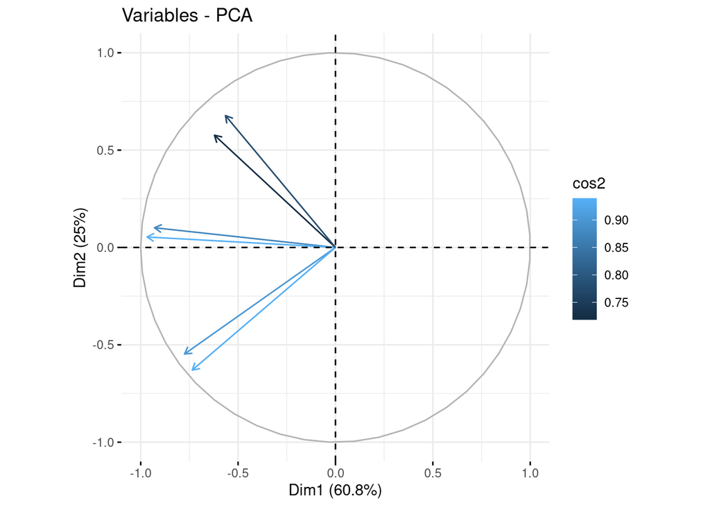

```r
fviz_pca_var(exp_gen_pca, col.var = "cos2",
             geom.var = "arrow",
             labelsize = 5,
             repel = F)
```

En el grafico se observa el % de la varianza explicada por el PC1 (Dim1) y PC2 (Dim2). La calidad de esta representación se mide por el valor al cuadrado del coseno (cos2) del ángulo del triángulo formado por el punto del origen, la observación y su proyección sobre el componente. Para una variable dada, la suma del cos2 sobre todos los componentes principales será igual a 1, y si además la variable es perfectamente representable por solo los dos primeros componentes principales, la suma de cos2 sobre estos dos será igual a 1. En este caso, los dos primeros componentes represeantan bien el sistema.

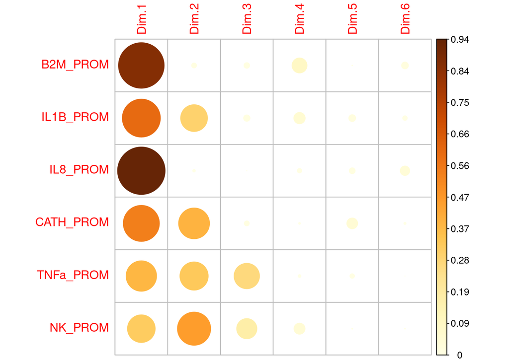

```r
var <- get_pca_var(exp_gen_pca)
corrplot(var$cos2, is.corr = FALSE)
```

PERMANOVA (Permutational multivariate analysis of variance)

Prueba No parametrica basada en la disimilitud. Puede reemplazar al ANOVA ya que es similar, permitiendo el análisis de diseños complejos (multiples variables).

Se calcula la disimilitud por metodo de bray curtis

```r
exp_gen.dist<-vegdist(D_PCA_new, method='bray')
summary (exp_gen.dist)
```

```
##    Min. 1st Qu.  Median    Mean 3rd Qu.    Max.
## 0.01039 0.05578 0.08616 0.08796 0.11844 0.20678
```

```r
set.seed(36) #reproducible results

exp_gen.div<-adonis2(exp_gen.dist~Group, data=D_PCA, permutations = 999, method="bray")
exp_gen.div
```

```
## Permutation test for adonis under reduced model
## Terms added sequentially (first to last)
## Permutation: free
## Number of permutations: 999
##
## adonis2(formula = exp_gen.dist ~ Group, data = D_PCA, permutations = 999, method = "bray")
##          Df SumOfSqs      R2    F Pr(>F)
## Group     6 0.069978 0.37223 3.36  0.003 **
## Residual 34 0.118018 0.62777
## Total    40 0.187996 1.00000
## ---
## Signif. codes:  0 '***' 0.001 '**' 0.01 '*' 0.05 '.' 0.1 ' ' 1
```

Si planteamos como hipotesis que:

H0= los grupos son iguales H1= los grupos son diferentes

A corde a los resultados del analisis podemos concluir que al menos un grupo es diferente

```r
set.seed(36) #reproducible results

exp_gen.div<-adonis2(exp_gen.dist~TREATMENT, data=D_PCA, permutations = 999, method="bray")
exp_gen.div
```

```
## Permutation test for adonis under reduced model
## Terms added sequentially (first to last)
## Permutation: free
## Number of permutations: 999
##
## adonis2(formula = exp_gen.dist ~ TREATMENT, data = D_PCA, permutations = 999, method = "bray")
##           Df SumOfSqs      R2      F Pr(>F)
## TREATMENT  1 0.012248 0.06515 2.7179  0.076 .
## Residual  39 0.175748 0.93485
## Total     40 0.187996 1.00000
## ---
## Signif. codes:  0 '***' 0.001 '**' 0.01 '*' 0.05 '.' 0.1 ' ' 1
```

La evaluacion por tratamiento indica que no existe diferencia entre Vacunados y no Vacunados.